# Housing Sales Prices of Houses in the City of Windsor Data

In this problem, we will work on the Housing dataset. The dataset is provided in CSV format, consists of multiple data samples. price lotsize bedrooms bathrms stories driveway recroom fullbase gashw airco garagepl prefarea

Below are the variable descriptions:

- **price** sale price of a house
- **lotsize** the lot size of a property in square feet
- **bedrooms** number of bedrooms
- **bathrms** number of full bathrooms
- **stories** number of stories excluding basement
- **driveway** does the house has a driveway ?
- **recroom** does the house has a recreational room ?
- **fullbase** does the house has a full finished basement ?
- **gashw** does the house uses gas for hot water heating ?
- **airco** does the house has central air conditioning ?
- **garagepl** number of garage places
- **prefarea** is the house located in the preferred neighbourhoods of the city ?

## Preparation phase

```python
from pyspark import SparkContext, SparkConf
from pyspark.rdd import RDD
from pyspark.sql import SparkSession
import os
os.environ["PYSPARK_PYTHON"] = "./spark/bin/python3"
conf=SparkConf().setMaster("yarn").setAppName("house-price-prediction") \
        .set("spark.yarn.dist.archives","spark.tar.gz#spark") \
        .set("spark.executor.cores", "4") \
        .set("spark.executor.memory", "1g") \
        .set("spark.driver.memory", "3g")
sc = SparkContext(conf=conf)
spark = SparkSession.builder.appName('house-price-prediction').getOrCreate()
```

```
Setting default log level to "WARN".
To adjust logging level use sc.setLogLevel(newLevel). For SparkR, use setLogLevel(newLevel).
```

```python
sc
```

**SparkContext**

[Spark UI](http://edge:4050)

**Version**

`v3.5.0`

**Master**

`yarn`

**AppName**

`house-price-prediction`

## Import necessary libraries

```python
import datetime
import numpy as np
%matplotlib inline
import matplotlib.pyplot as plt
from pyspark.sql.functions import col, when, log, lit
from pyspark.ml.feature import VectorAssembler
from pyspark.ml.evaluation import RegressionEvaluator
```

## Read and display the data

```python
file_path = "Housing_large.csv"
partition = 8
```

I drop the first column of the dataframe since it contains only the index.

```python
df = spark.read.csv(os.path.join("data", file_path), header=True).drop('_c0')
header = df.columns
df = df.repartition(partition)
```

Since the columns that contain binary category only take two values "yes" or "no", I will map "yes" to 1 and "no" to 0. I also take the logarithm value of two colums lotsize and price since their raw values are too high.

```python
binary_columns = ["driveway", "recroom", "fullbase", "gashw", "airco", "prefarea"]
for column in binary_columns:
    df = df.withColumn(column, when(col(column) == 'yes', 1).otherwise(0))
for col_name in header:
    df = df.withColumn(col_name, col(col_name).cast("float"))
df= df.withColumn("price", log(col("price"))).withColumn("lotsize", log(col("lotsize"))) \
        .withColumnRenamed("price", "log(price)").withColumnRenamed("lotsize", "log(lotsize)")
df = df.withColumn("theta_0", lit(1))
header.append("theta_0")
features = df.columns[1:]
df.show(5)
```

```
+------------------+-----------------+--------+-------+-------+--------+-------+--------+-----+-----+--------+--------+-------+
|        log(price)|     log(lotsize)|bedrooms|bathrms|stories|driveway|recroom|fullbase|gashw|airco|garagepl|prefarea|theta_0|
+------------------+-----------------+--------+-------+-------+--------+-------+--------+-----+-----+--------+--------+-------+
| 13.12156305723356| 9.90193635004339|     3.0|    3.0|    4.0|     1.0|    1.0|     0.0|  0.0|  1.0|     1.0|     0.0|      1|
|10.239959789157341| 8.13739583005665|     5.0|    1.0|    2.0|     0.0|    0.0|     0.0|  0.0|  0.0|     0.0|     0.0|      1|
|11.842948377911535|9.757478638400492|     1.0|    1.0|    1.0|     1.0|    0.0|     0.0|  0.0|  0.0|     2.0|     0.0|      1|
|11.429543856031177|8.517193191416238|     3.0|    1.0|    2.0|     1.0|    0.0|     0.0|  0.0|  1.0|     0.0|     0.0|      1|
|11.461632170582678|8.648221453822641|     3.0|    1.0|    1.0|     1.0|    1.0|     1.0|  0.0|  1.0|     2.0|     1.0|      1|
+------------------+-----------------+--------+-------+-------+--------+-------+--------+-----+-----+--------+--------+-------+
only showing top 5 rows
```

## Convert the features into vector and perform a 70/30 train-test split.

```python
assembler = VectorAssembler(inputCols=features, outputCol="features")
transform_df = assembler.transform(df).select(*["features","log(price)"])
(train_data, test_data) = transform_df.randomSplit([0.7, 0.3], seed=1)
```

Here I set the learning_rate to 0.0005, which I believe enough for not overshooting the minimum of the loss function and not taking to long to run.

```python
def stochastic_gradient_descent(f, x, y, theta):
    learning_rate = 0.0005
    indices = np.random.permutation(len(x))
    for i in indices:
        y_hat=f(x[i], theta)
        loss =0.5*(y_hat-y[i])**2
        gradient = (y_hat-y[i])*x[i]
        theta -= learning_rate * gradient

    return theta
# Linear regression function
def linear_regression(x, theta):
    return np.dot(x, theta)

def make_prediction(row):
    return row[0], row[1], row[0].toArray().dot(learned_theta)
```

I set the condition for convergence to 0.0001, this means if the difference between the two lastest rmse is less than 0.0001, they will be considered the same, where the rmse starts to converge. I also set the max_iteration to 1000 in case it does not converge.

```python
rmse = []
learned_theta = np.ones(len(header)-1)
x = np.array(train_data.select("features").rdd.map(lambda r: r[0].toArray()).collect())
y = np.array(train_data.select("log(price)").rdd.map(lambda r: r[0]).collect())
for iteration in range(1000):
    learned_theta = stochastic_gradient_descent( linear_regression, x, y, learned_theta)
    prediction = test_data.rdd.map(make_prediction)
    rmse.append(prediction.map(lambda row: (row[2] - row[1]) ** 2).mean() ** 0.5)
    if (iteration>10) and (abs(1-rmse[-1]/rmse[-2])<0.0001):
        break
```

## Plot RMSE values

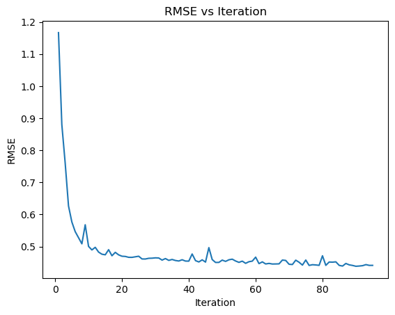

```python
plt.plot(range(1, len(rmse) + 1), rmse)
plt.xlabel('Iteration')
plt.ylabel('RMSE')
plt.title('RMSE vs Iteration')
plt.show()
```

```python
equation = "log(price) = " + " + ".join([f"{coef:.2f}*{var}" for coef, var in zip(learned_theta[:-1],df.columns[1:-1])]) + " + " + str(learned_theta[-1])
print(equation)
print("RMSE:", rmse[-1])
```

```
log(price) = 0.97*log(lotsize) + 0.04*bedrooms + 0.13*bathrms + 0.13*stories + 0.01*driveway + -0.06*recroom + 0.21*fullbase + 0.19*gashw + 0.01*airco + -0.03*garagepl + 0.03*prefarea + 2.149752938238865
RMSE: 0.4414825790428499
```